# Econ220 Lab Final Project

# Introduction and Motivation

My project focuses on the relationships between student’s mobile-phone selection and their expect spending on clothing each semester as well as their expect annual salary in the first year out of the college. By digging into this topic, I believe that my results can give people insight into how mobile phones can have an effect on our budget planning and confidence in the future job market.

From my past experience I have noticed that Android users and Iphone users all come from different economical background and social beliefs. For example, some people use Iphone because it’s trendy and using it makes the users feel more included when socializing with others since Apple now has a more inclusive product environment. On the other side, Android users may be the people who value the function and flexibility in Android phones which has more utility than the Iphones. Therefore, Iphone users may spend more money on clothing each semester and have a higher expected salary in the first year post-graduation than Android users. Therefore, in this project I will treat the category of smartphones that students use as independent variable, and their expect spending on clothing each semester and expected income in the first year after graduation as the dependent variables.

## Hypothesis

#### Question #1: Do Iphone users spend more on clothing each semester than Android users?

- **Null hypothesis**: There’s no significant relationship between smartphone choices and semester budget for clothing.
- **Alternative hypothesis**: There’s is significant relationship between smartphone choices and semester budget for clothing. Iphone users spend more on clothing each semester than Android users.

#### Question #2: Do Iphone users have higher expected income in the first year after graduated than Android users?

- **Null hypothesis**: There’s no significant relationship between smartphone choices and expected income in the first year after graduated than Android users.
- **Alternative hypothesis**: There’s is significant relationship between smartphone choices and expected income in the first year after graduated than Android users. Iphone users have a higher expected income in the first year after graduation than Android users.

## External reources

There are several external studies that agree with my alternative hypothesis. For example, one of the leading crowdsourced shopping platform [Slickdeals](https://slickdeals.net/) has conducted survey to 1,000 iphone users and 1,000 Android users asking about their lifestyle choices, and the results show that iphone users have a higher average spending on clothes ($54.77 difference) than Android users. In addition, the survey also shows that iphone users have an average salary of $53,251 while android users have an average salary of $37,040.

[figure not shown]

Figure1: from [Slickdeals](https://slickdeals.net/)

Furthermore, another study also examines the difference in User’s risk and security perception of Android and Iphone. In [*Should the Users be Informed? On Differences in Risk Perception between Android and iPhone Users*](http://citeseerx.ist.psu.edu/viewdoc/download?doi=10.1.1.386.353&rep=rep1&type=pdf) (Benenson et al. 2014), researchers conclude that Android users tend to be more aware of potential risks and security threats comparing to Iphone users from the result of 700 surveys. Not only does this research offer insight into the social behavior difference between Android and Iphone users, but it also serves as a base for this project to elaborate more on how choice of smartphone can have an effect on our budget spending behavior and confidence in future income.

Although academic research regarding specific smartphone brand on social behavior is limited, I have found other paper suggesting a correlation between usage of communication technology and academic success. In [*Cell phone usage and academic performance: An experiment*](https://www.sciencedirect.com/science/article/pii/S0360131517302324#sec4) (Felisoni et al. 2018), the author suggests a strong significant negative correlation between communication technology and academic performance. This result is also demonstrated with the graph shown blow:

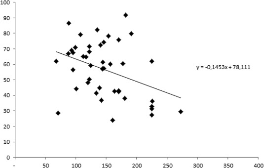

Figure2: from [Cell phone usage and academic performance: An experiment](https://www.sciencedirect.com/science/article/pii/S0360131517302324#sec4)

Therefore, my study would continue to build on the past studies and look at how difference in smartphone OS choices would affect student’s expected income in the first year after graduated as well as their budget on clothing in each semester.

## Data Cleaning

First I load variables of interest into a new data frame and rename them.

```r
# transfer all variables of interest into new data frame called allvariabels

# rename
#57 - iphone or android
#52 - expected first year salary out of college
#39 - money on cloth per semester
allvariables <- Econ220DataF20_ano%>%
  select(iphone_or_android = q57, first_year_salary = q52, semester_cloth_budget = q39)

# look at the new data
allvariables[1:10,]
```

```
   iphone_or_android first_year_salary semester_cloth_budget
1             Iphone             90000                     0
2            Android             50000                   100
3             Iphone             70000                   200
4             Iphone             65000                   300
5             Iphone             50000                    $0
6             Iphone             70000                   $20
7             Iphone             60000                   150
8             Iphone             70000                   300
9             Iphone             60000                    50
10            Iphone             60000                   400
```

Now I need to check the data and exclude potential outliers and NA.

### Check NA

```r
# check the dataset
summary(allvariables)
```

```
 iphone_or_android  first_year_salary semester_cloth_budget
 Length:138         Min.   :     0    Length:138
 Class :character   1st Qu.: 50721    Class :character
 Mode  :character   Median : 65000    Mode  :character
                    Mean   : 72693
                    3rd Qu.: 80000
                    Max.   :600000
```

```r
str(allvariables)
```

```
'data.frame':   138 obs. of  3 variables:
 $ iphone_or_android    : chr  "Iphone" "Android" "Iphone" "Iphone" ...
 $ first_year_salary    : num  90000 50000 70000 65000 50000 70000 60000 70000 60000 60000 ...
 $ semester_cloth_budget: chr  "0" "100" "200" "300" ...
```

```r
# check number of NA in the dataset
sum(is.na(allvariables))
```

```
[1] 0
```

```r
# there's no NA
```

### Iphone or Android Users

```r
# convert iphone_or_android to factors with two levels
allvariables$iphone_or_android <- factor(allvariables$iphone_or_android, levels = c("Android",
    "Iphone"))
levels(allvariables$iphone_or_android)
```

[output not shown]

### Expected Salary After 1st Year of Gradution

```r
# check first_year_salary variable
summary(allvariables$first_year_salary)
```

```
   Min. 1st Qu.  Median    Mean 3rd Qu.    Max.
      0   50721   65000   72693   80000  600000
```

```r
# it's impossible to have 0 in this variable, hence removing 0
allvariables <- allvariables[allvariables$first_year_salary > 0, ]
# Remove observations highers than 200k.
allvariables$first_year_salary[allvariables$first_year_salary > 2e+05] <- NA
```

According to the article “Average Starting Salary for Recent College Grads Hovers Near $51,000” published on shrm.org using data from [National Association of Colleges and Employers (NACE)](https://www.naceweb.org/uploadedfiles/files/2019/publication/executive-summary/2019-nace-salary-survey-summer-executive-summary.pdf), the average salary for first year graduate is about $51,000. Therefore, it’s unusual to have an expected salary of more than 200k. Hence removing any observations that have more than 200k of expected salary.

### Semester Cloth Budget

```r
# check semester_cloth_budget
table(allvariables$semester_cloth_budget)
```

```
   $0  $100   $20     0 1,500   100  1000   145    15   150  1500    20   200
    1     2     1     4     1    20     8     1     1     9     1     3    16
 2000   250  2500   260    30   300  3000   350    40   400  4000   450    50
    5     4     1     1     3    13     2     2     2     5     2     1     9
  500  5000    60   600   700    80  8000
   10     2     1     1     1     1     1
```

```r
# convert $0, $100 and $20 to number
allvariables$semester_cloth_budget[allvariables$semester_cloth_budget == "$0"] <- "0"
allvariables$semester_cloth_budget[allvariables$semester_cloth_budget == "$20"] <- "20"
allvariables$semester_cloth_budget[allvariables$semester_cloth_budget == "$100"] <- "100"
# convert variable to numeric variable
allvariables$semester_cloth_budget <- as.numeric(allvariables$semester_cloth_budget)

summary(allvariables$semester_cloth_budget)
```

```
   Min. 1st Qu.  Median    Mean 3rd Qu.    Max.    NA's
    0.0   100.0   200.0   569.9   487.5  8000.0       1
```

### Remove NA

```r
# remove NA
allvariables <- na.omit(allvariables)
summary(allvariables)
```

```
 iphone_or_android first_year_salary semester_cloth_budget
 Android: 12       Min.   :  2000    Min.   :   0.0
 Iphone :120       1st Qu.: 58221    1st Qu.: 100.0
                   Median : 65000    Median : 200.0
                   Mean   : 67058    Mean   : 539.5
                   3rd Qu.: 80000    3rd Qu.: 462.5
                   Max.   :200000    Max.   :8000.0
```

## Corrected data

Create two subsets of just Iphone or Android users

```r
iphone_usr <- allvariables %>% filter(iphone_or_android == "Iphone")
android_usr <- allvariables %>% filter(iphone_or_android == "Android")
```

Below is the table of my corrected data

```r
datatable(allvariables, rownames = FALSE, filter = "top", options = list(pageLength = 5,
    scrollX = T))
```

| iphone_or_android | first_year_salary | semester_cloth_budget |
| --- | --- | --- |
| Iphone | 90000 | 0 |
| Android | 50000 | 100 |
| Iphone | 70000 | 200 |
| Iphone | 65000 | 300 |
| Iphone | 50000 | 0 |
| Iphone | 70000 | 20 |
| Iphone | 60000 | 150 |
| Iphone | 70000 | 300 |
| Iphone | 60000 | 50 |
| Iphone | 60000 | 400 |

[output cut: 122 more lines]

# Graphs and Analysis

## Distribution of Android and Iphone Users

Here are the proportion distribution table and graph of Android and Iphone Users from the dataset.

#### Table

```r
kable(prop.table(table(allvariables$iphone_or_android)), col.names = c("OS", "Proportion"),
    caption = "Table of Proportion Distribution of OS Users", digits = 4) %>% kable_styling(position = "center",
    bootstrap_options = "striped", full_width = F)
```

Table of Proportion Distribution of OS Users

| OS | Proportion |
| --- | --- |
| Android | 0.0909 |
| Iphone | 0.9091 |

#### Graph

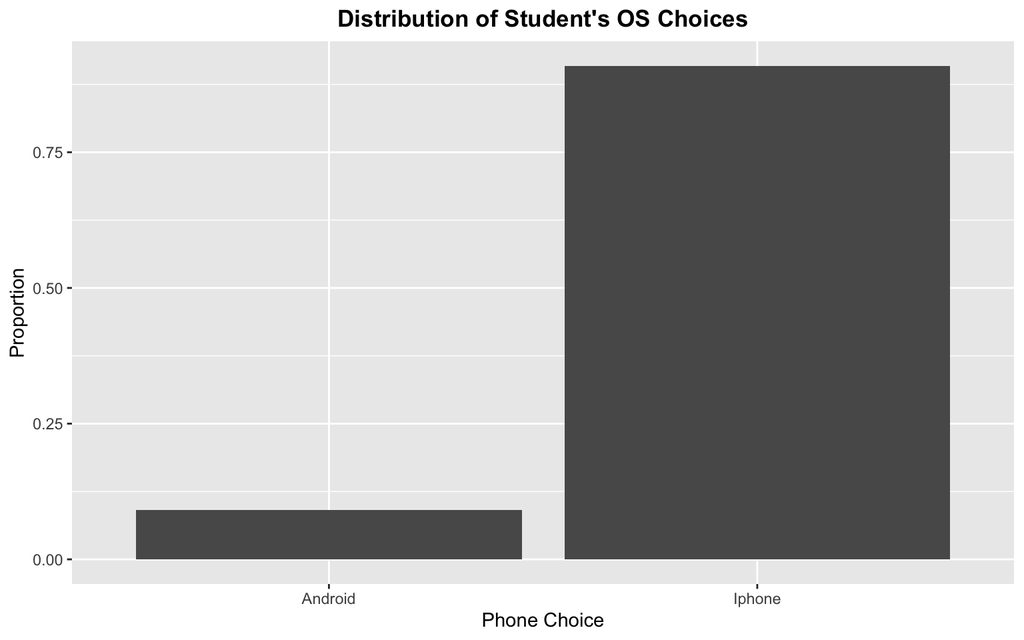

```r
# check the proportion
ggplot(allvariables) + geom_bar(mapping = aes(x = iphone_or_android, y = ..prop..,
    group = 1), stat = "count") + xlab("Phone Choice") + ylab("Proportion") + ggtitle("Distribution of Student's OS Choices") +
    theme(plot.title = element_text(hjust = 0.5, face = "bold"))
```

## Distribution of Budget for Clothing Each Semester

#### Descriptive Statistics

```r
# check the descriptive statistics of cloth budget in each semester
table(allvariables$iphone_or_android)
```

```
Android  Iphone
     12     120
```

```r
allvariables %>% group_by(iphone_or_android) %>% dplyr::summarise(Observation = n(),
    Mean = mean(semester_cloth_budget), `Standard Deviation` = sd(semester_cloth_budget),
    `Standard Error` = std.error(semester_cloth_budget)) %>% kable(digits = 3, caption = "Summary Statistics of Semester Clothing Budget Variable") %>%
    kable_styling(position = "center", bootstrap_options = "striped", full_width = F)
```

Summary Statistics of Semester Clothing Budget Variable

| iphone_or_android | Observation | Mean | Standard Deviation | Standard Error |
| --- | --- | --- | --- | --- |
| Android | 12 | 552.500 | 1402.784 | 404.949 |
| Iphone | 120 | 538.208 | 1015.091 | 92.665 |

```r
summary(iphone_usr$semester_cloth_budget)
```

```
   Min. 1st Qu.  Median    Mean 3rd Qu.    Max.
    0.0   100.0   200.0   538.2   500.0  8000.0
```

```r
summary(android_usr$semester_cloth_budget)
```

```
   Min. 1st Qu.  Median    Mean 3rd Qu.    Max.
   80.0   100.0   100.0   552.5   225.0  5000.0
```

#### Histogram

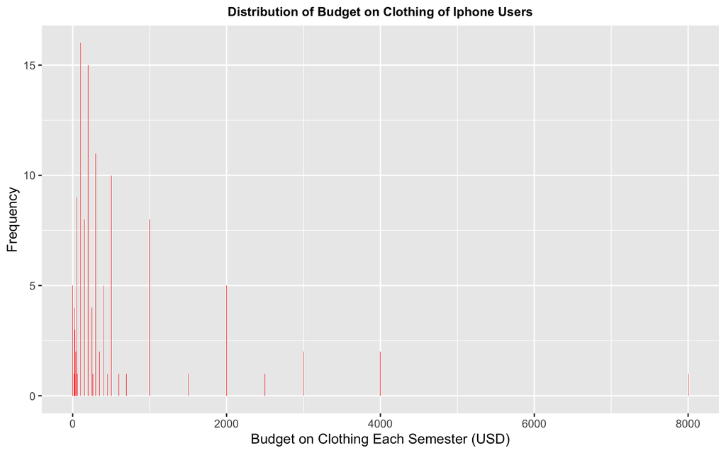

```r
# graph histograms to show distribution of clothing budget by phone OS.
ggplot(iphone_usr, aes(x = semester_cloth_budget)) + geom_bar(fill = "red") + xlab("Budget on Clothing Each Semester (USD)") +
    ylab("Frequency") + ggtitle("Distribution of Budget on Clothing of Iphone Users") +
    theme(plot.title = element_text(hjust = 0.5, size = 10, face = "bold"))
```

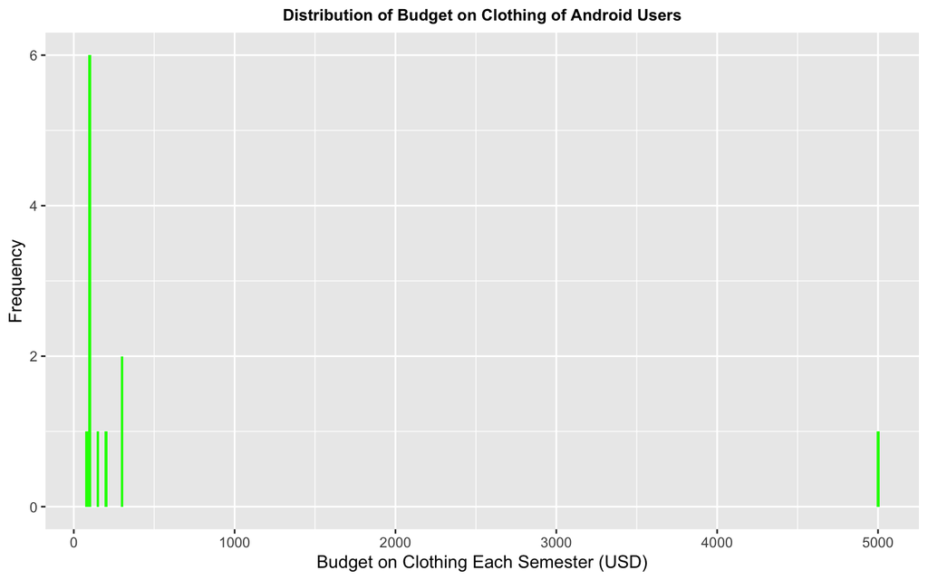

```r
ggplot(android_usr, aes(x = semester_cloth_budget)) + geom_bar(fill = "green") +
    xlab("Budget on Clothing Each Semester (USD)") + ylab("Frequency") + ggtitle("Distribution of Budget on Clothing of Android Users") +
    theme(plot.title = element_text(hjust = 0.5, size = 10, face = "bold"))
```

#### Boxplot

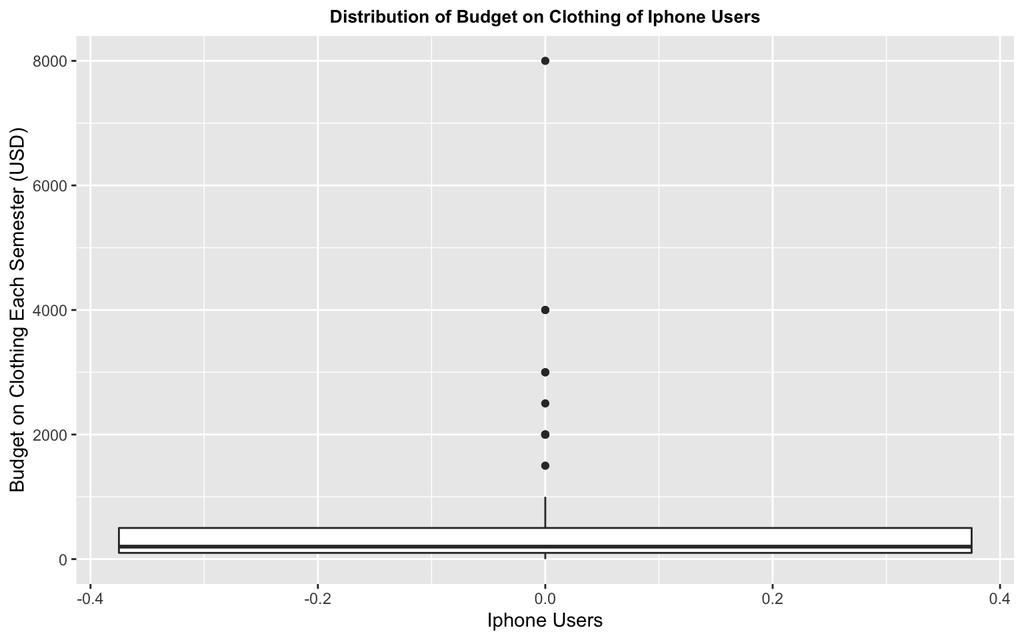

```r
ggplot(iphone_usr, aes(y = semester_cloth_budget)) + geom_boxplot() + xlab("Iphone Users") +
    ylab("Budget on Clothing Each Semester (USD)") + ggtitle("Distribution of Budget on Clothing of Iphone Users") +
    theme(plot.title = element_text(hjust = 0.5, size = 10, face = "bold"))
```

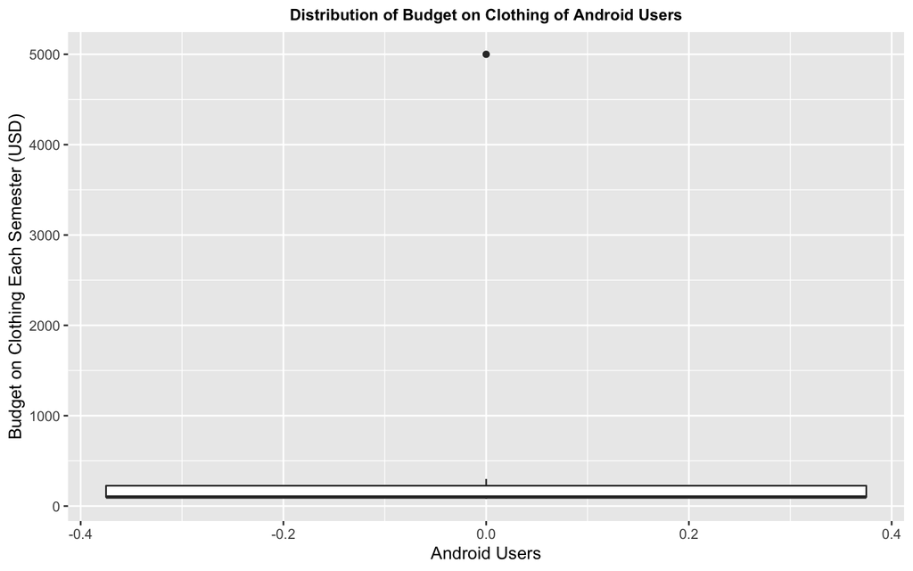

```r
ggplot(android_usr, aes(y = semester_cloth_budget)) + geom_boxplot() + xlab("Android Users") +
    ylab("Budget on Clothing Each Semester (USD)") + ggtitle("Distribution of Budget on Clothing of Android Users") +
    theme(plot.title = element_text(hjust = 0.5, size = 10, face = "bold"))
```

Although the number of observations for the Android users is far fewer than that of Iphone users, the histogram shows the distributions of both groups and demonstrates the difference and similarity between the two groups clearly.

## Distribution of Expected Salary in the First Year after Graduation

#### Descriptive Statistics

```r
# check the descriptive statistics of expected salary in the first year after
# graduation
allvariables %>% group_by(iphone_or_android) %>% dplyr::summarise(Observation = n(),
    Mean = mean(first_year_salary), `Standard Deviation` = sd(first_year_salary),
    `Standard Error` = std.error(first_year_salary)) %>% kable(digits = 3, caption = "Summary Statistics of Expected First irst Year Salary in the First Year after Graduation Variable") %>%
    kable_styling(position = "center", bootstrap_options = "striped", full_width = F)
```

Summary Statistics of Expected First irst Year Salary in the First Year after Graduation Variable

| iphone_or_android | Observation | Mean | Standard Deviation | Standard Error |
| --- | --- | --- | --- | --- |
| Android | 12 | 59823.75 | 13056.70 | 3769.144 |
| Iphone | 120 | 67781.33 | 25260.46 | 2305.954 |

```r
summary(iphone_usr$first_year_salary)
```

```
   Min. 1st Qu.  Median    Mean 3rd Qu.    Max.
   2000   60000   68500   67781   80000  200000
```

```r
summary(android_usr$first_year_salary)
```

```
   Min. 1st Qu.  Median    Mean 3rd Qu.    Max.
  40000   50000   56442   59824   70000   80000
```

#### Histogram

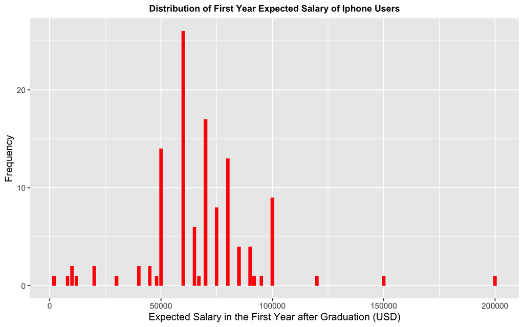

```r
# graph histograms to show distribution of expected salary in the first year
# after graduation by phone OS.
ggplot(iphone_usr, aes(x = first_year_salary)) + geom_bar(fill = "red") + xlab("Expected Salary in the First Year after Graduation (USD)") +
    ylab("Frequency") + ggtitle("Distribution of First Year Expected Salary of Iphone Users") +
    theme(plot.title = element_text(hjust = 0.5, size = 10, face = "bold"))
```

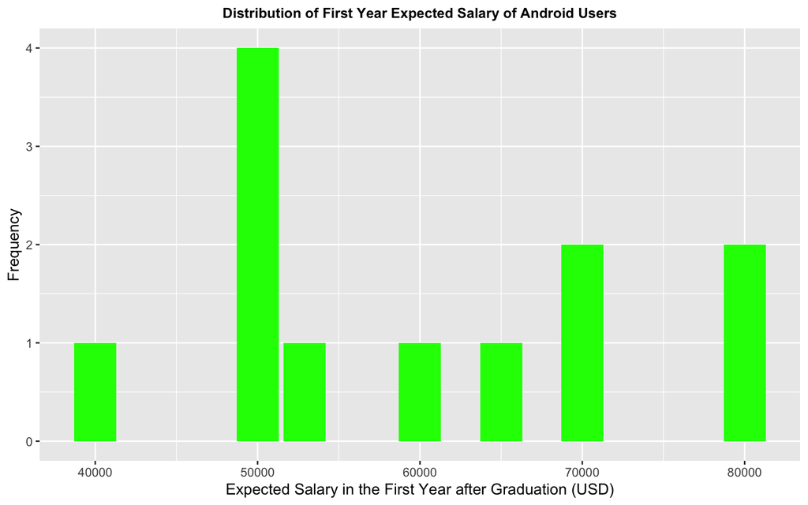

```r
ggplot(android_usr, aes(x = first_year_salary)) + geom_bar(fill = "green") + xlab("Expected Salary in the First Year after Graduation (USD)") +
    ylab("Frequency") + ggtitle("Distribution of First Year Expected Salary of Android Users") +
    theme(plot.title = element_text(hjust = 0.5, size = 10, face = "bold"))
```

#### Boxplot

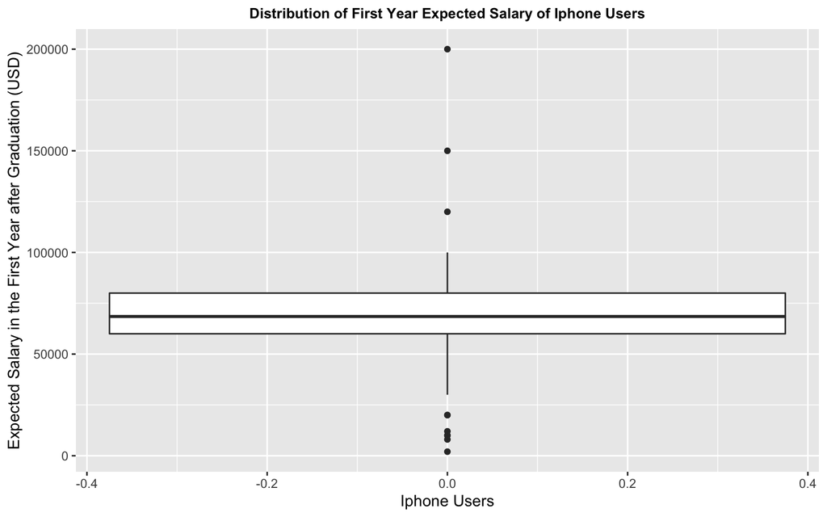

```r
ggplot(iphone_usr, aes(y = first_year_salary)) + geom_boxplot() + xlab("Iphone Users") +
    ylab("Expected Salary in the First Year after Graduation (USD)") + ggtitle("Distribution of First Year Expected Salary of Iphone Users") +
    theme(plot.title = element_text(hjust = 0.5, size = 10, face = "bold"))
```

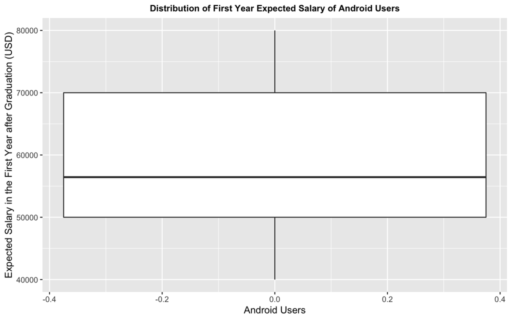

```r
ggplot(android_usr, aes(y = first_year_salary)) + geom_boxplot() + xlab("Android Users") +
    ylab("Expected Salary in the First Year after Graduation (USD)") + ggtitle("Distribution of First Year Expected Salary of Android Users") +
    theme(plot.title = element_text(hjust = 0.5, size = 10, face = "bold"))
```

By looking at the graphs and tables, we can see that the boxplot best summarizes the two variables while the histogram for Iphone users is the best in showing the distribution of observations. The distribution histogram of Iphone users’ expected first year salary after graduation approximate a normal distribution but a bit skew to the right.

# Analysis Confidence Intervals Testing

In this section I will answer my questions in the first section using hypothesis testing to see if the difference in means are significant in both questions. The questions are shown below:

#### Question #1: Do Iphone users spend more on clothing each semester than Android users?

- **Null hypothesis**: There’s no significant relationship between smartphone choices and semester budget for clothing.
- **Alternative hypothesis**: There’s is significant relationship between smartphone choices and semester budget for clothing. Iphone users spend more on clothing each semester than Android users.

#### Question #2: Do Iphone users have higher expected income in the first year after graduated than Android users?

- **Null hypothesis**: There’s no significant relationship between smartphone choices and expected income in the first year after graduated than Android users.
- **Alternative hypothesis**: There’s is significant relationship between smartphone choices and expected income in the first year after graduated than Android users. Iphone users have a higher expected income in the first year after graduation than Android users.

## Do Iphone users spend more on clothing each semester than Android users?

First let’s compare the mean semester budget on clothing by different OS users.

```r
allvariables %>% group_by(iphone_or_android) %>% dplyr::summarise(Average_budget = mean(semester_cloth_budget)) %>%
    kable(digits = 3) %>% kable_styling(bootstrap_options = "striped", full_width = F)
```

| iphone_or_android | Average_budget |
| --- | --- |
| Android | 552.500 |
| Iphone | 538.208 |

From the table a higher mean is observed in Android users, which objects our hypothesis. Now let’s conduct hypothesis test to see if the difference in mean is significant

```r
t.test(semester_cloth_budget ~ iphone_or_android, data = allvariables)
```

```
    Welch Two Sample t-test

data:  semester_cloth_budget by iphone_or_android
t = 0.034403, df = 12.179, p-value = 0.9731
alternative hypothesis: true difference in means is not equal to 0
95 percent confidence interval:
 -889.3478  917.9311
sample estimates:
mean in group Android  mean in group Iphone
             552.5000              538.2083
```

This result is largely due to lack of observations of Android users. If we have more observations of Android users (for example, 200 IOS users and 200 Android users), the test may yield a different result.

## Do Iphone users have higher expected income in the first year after graduing colege than than Android users?

Let’s then compare the mean expected salary in the first year after graduation by different OS users.

```r
allvariables %>% group_by(iphone_or_android) %>% dplyr::summarise(Average_expectation = mean(first_year_salary)) %>%
    kable(digits = 3) %>% kable_styling(bootstrap_options = "striped", full_width = F)
```

| iphone_or_android | Average_expectation |
| --- | --- |
| Android | 59823.75 |
| Iphone | 67781.33 |

Now let’s conduct hypothesis testing to see if the difference in means is significant.

```r
t.test(first_year_salary ~ iphone_or_android, data = allvariables)
```

```
    Welch Two Sample t-test

data:  first_year_salary by iphone_or_android
t = -1.8009, df = 20.51, p-value = 0.08644
alternative hypothesis: true difference in means is not equal to 0
95 percent confidence interval:
 -17159.913   1244.746
sample estimates:
mean in group Android  mean in group Iphone
             59823.75              67781.33
```

# Conclusion and Summary

## Based onour findings

This project is designed to find the correlation between students’ phone OS choices and their semester budget on clothing, in addition to the relationship between students’ phone OS choices and their expected income in the first year after graduating college.

The two hypotheses driving this analysis are: 1) Iphone users spend more on clothing each semester than Android users 2) Iphone users have a higher expected income in the first year after graduation than Android users.

These two hypotheses are based on the survey conducted by [Slickdeals](https://slickdeals.net/) as well as the research from [*Cell phone usage and academic performance: An experiment*](https://www.sciencedirect.com/science/article/pii/S0360131517302324#sec4) (Felisoni et al. 2018). These two studies offer insight into the correlation between smartphone OS users and their social behavior, spending on clothing, average income, and other characteristics. In the survey, results suggest that Iphone users tend to have higher average income and clothing spending compare to Android users, which implicate that Iphone users typically have higher standard of living. Although this conclusion concur with the stereotype of high pricing of Iphone comparing with Anroid OS phones, I disagree with this conclusion because it’s possible that Iphone users prioritize functionality over pricing, hence the reason of choosing Iphone or Android. Therefore, by investigating this topic, I can gain more insight into how choices of smart phone OS correlates with social behaviors and personal spending habits.

Despite the results of hypothesis testing denies a statistically significant result for either hypotheses, this rejection can be explained by several factors. First, since the sample is drawn from a voluntary survey of students in Econ-220 Lab: Probability & Statistics for Economists Lab, it can introduce uncertainty in sample observations. For example, in the 132 observations from the dataset, only 12 people use Android OS comparing with 120 Iphone users. This unbalanced proportion is due to the small sample size. If we are able to survey more students and replicate the same survey randomly, we may get more Android users and produce significant results in the later hypothesis testing. However, a natural bias with this survey method is the demographic of respondents. Since all samples are taken from Econ-220 Lab: Probability & Statistics for Economists Lab at Emory, it’s possible that most people have higher standard of living comparing with students from other schools. Therefore, it’s reasonable for most students in this survey to choose Iphone because they can afford it. Another factor that may introduces error to the study is self-report data collection method. Since all response are reported by students themselves, it’s likely that some of them provided non-accurate response if they didn’t treat the survey seriously.

## Application and Future Work

As I have discussed in the previous section, future study on the same topic will able to produce more significant result when more random samples are taken outside the scope of Econ-220 Lab: Probability & Statistics for Economists Lab. In addition, under the condition of COVID-19, it would be interesting to examine the difference of study effeciency by different OS user group since mobile communication is one of the most important function for students especially during the pandemic. With more random samples and good data, this study will becmome more significant and offer insight into the correlation between smartphone OS and other social behavior in the future.